# Reproducible Research : Course Project 1

## Loading and preprocessing the data

### 1. Load the data

```r
library(dplyr)
library(ggplot2)

if(!file.exists('activity.csv')){
  unzip('activity.zip')
}
data <- read.csv('activity.csv')
```

### 2. Process/transform the data (if necessary) into a format suitable for your analysis

Not necessary

## What is mean total number of steps taken per day?

### 1. Calculate the total number of steps taken per day

```r
stepsByDate <- data %>%
  group_by(date) %>%
  summarize(total_step = sum(steps, na.rm = TRUE))
```

### 2. Make a histogram of the total number of steps taken each day

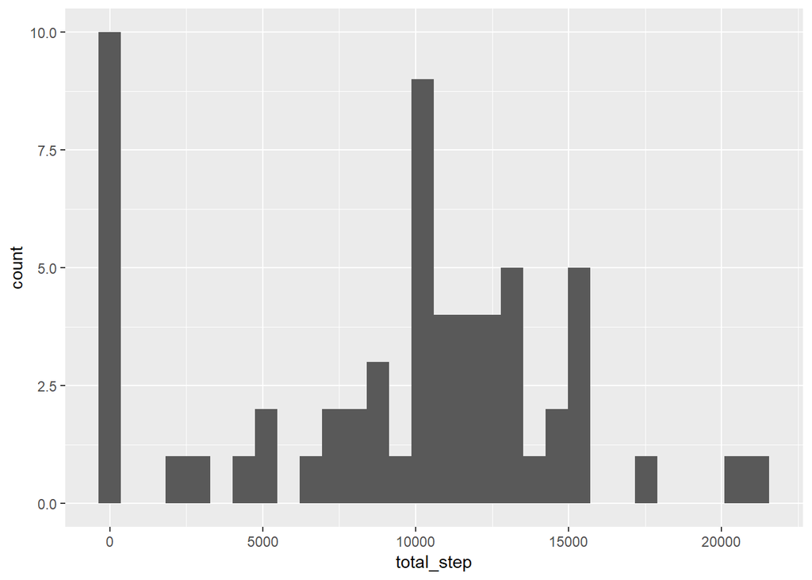

```r
ggplot(stepsByDate, aes(x=total_step)) + geom_histogram()
```

### 3. Calculate and report the mean and median of the total number of steps taken per day

```r
mean(stepsByDate$total_step)
```

```
## [1] 9354.23
```

```r
median(stepsByDate$total_step)
```

```
## [1] 10395
```

## What is the average daily activity pattern ?

### 1. Make a time series plot of the 5-minute interval (x-axis) and the average number of steps taken, averaged across all days (y-axis)

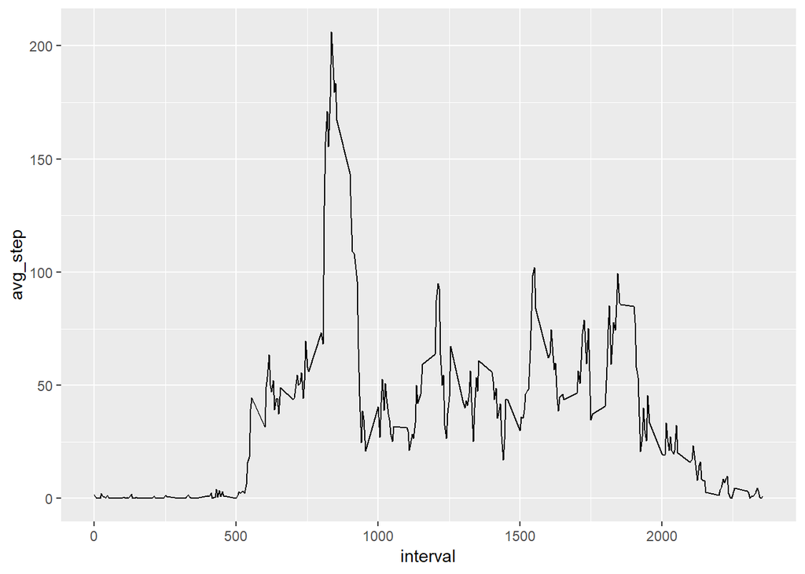

```r
stepsBy5Mins <- data %>%
  group_by(interval) %>%
  summarize(avg_step = mean(steps, na.rm = TRUE))

ggplot(data=stepsBy5Mins, aes(x=interval, y=avg_step, group=1)) + geom_line()
```

### 2. Which 5-minute interval, on average across all the days in the dataset, contains the maximum number of steps?

```r
stepsBy5Mins[stepsBy5Mins$avg_step == max(stepsBy5Mins$avg_step) ,][[1]]
```

```
## [1] 835
```

## Imputing missing values

### 1. Calculate and report the total number of missing values in the dataset

```r
length(data[is.na(data)])
```

```
## [1] 2304
```

### 2. Devise a strategy for filling in all of the missing values in the dataset

My strategy is filling missing values with mean

### 3. Create a new dataset that is equal to the original dataset but with the missing data filled in

```r
imputedData <- data
imputedData$steps[is.na(imputedData$steps)] = mean(imputedData$steps, na.rm=TRUE)
```

### 4. Make a histogram of the total number of steps taken each day and Calculate and report the mean and median total number of steps taken per day

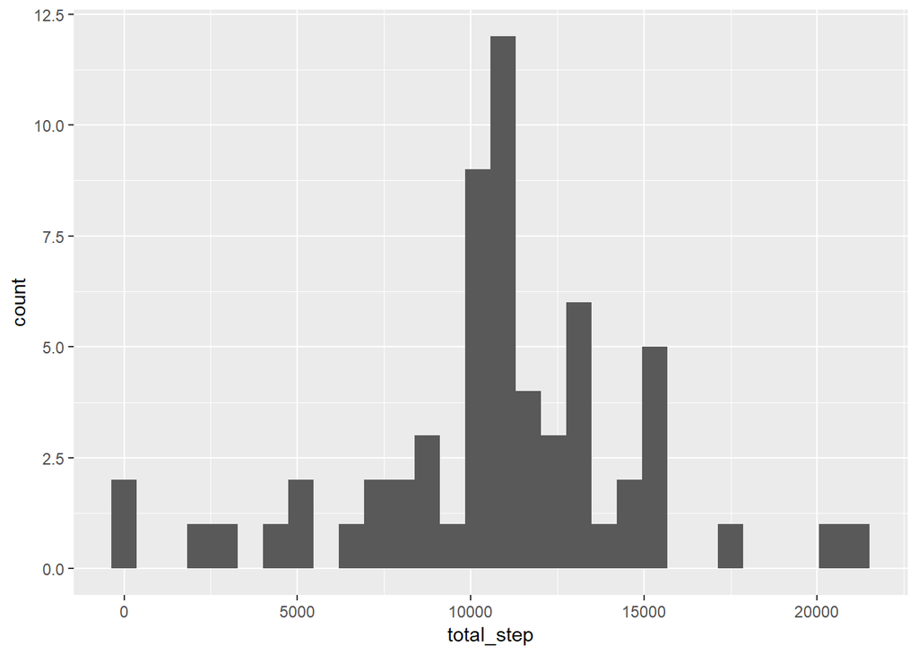

```r
imputedStepsByDate <- imputedData %>%
  group_by(date) %>%
  summarize(total_step = sum(steps, na.rm = TRUE))

ggplot(imputedStepsByDate, aes(x=total_step)) + geom_histogram()
```

```r
mean(imputedStepsByDate$total_step)
```

```
## [1] 10766.19
```

```r
median(imputedStepsByDate$total_step)
```

```
## [1] 10766.19
```

## Are there differences in activity patterns between weekdays and weekends ?

```r
imputedData$dateType <- ifelse(weekdays(as.POSIXlt(imputedData$date)) %in% c('Sunday','Saturday'), 'weekend', 'weekday')

imputedStepsBy5Mins <- imputedData %>%
  group_by(interval, dateType) %>%
  summarize(avg_step = mean(steps, na.rm = TRUE))
```

### 2. Make a panel plot containing a time series plot of the 5-minute interval (x-axis) and the average number of steps taken, averaged across all weekday days or weekend days (y-axis)

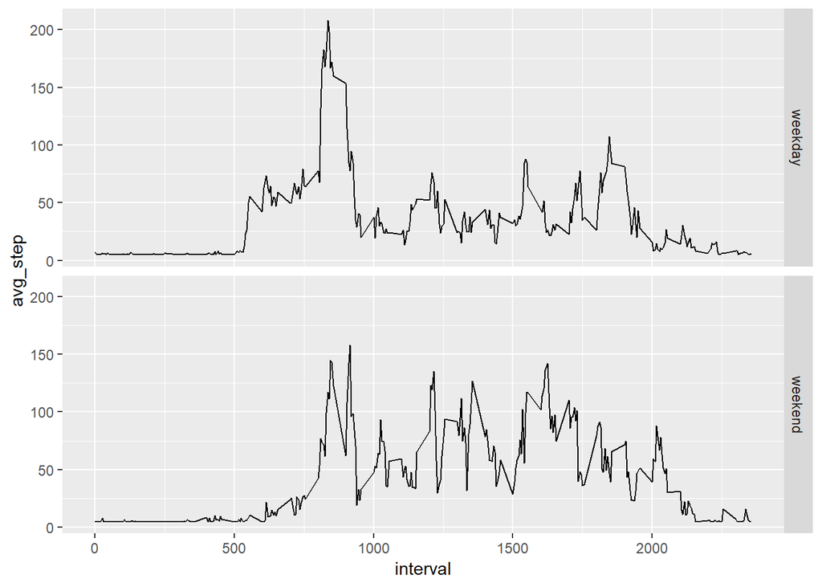

```r
ggplot(data=imputedStepsBy5Mins, aes(x=interval, y=avg_step)) +
  geom_line() +
  facet_grid(dateType ~ .)
```